# MIA

Flavio Lichtenstein

Wednesday, April 29, 2015

## How to install

There are two ways to install:

- clone the project via github
- download the project

## How to clone?

Here are the commands to clone MIA project:

- Install GitHub application
  - for windows: [click here](https://github.com/)
  - for linux give the following command: **sudo apt-get install git**
- Run GitHub and write the following commands:

git init git clone https://github.com/flalix/mia/

## How to download?

- Go to [MIA site](https://github.com/flalix/mia/) and click in download
- Click in **download**

[figure not shown]

- Create a directory in windows:

cd c:\Users\your_name  
md mia

- Create a directory in linux:

cd ~  
mkdir mia

- and **decompress the zip file here in mia directory**

## Running MIA

Once cloned or dowloaded (and unziped) MIA archives, you will find the executable file (binary) at:

- if windows: c:\user\your_name\mia\exe\windows
- if linux: ~/mia/exe/linux

Give a double click in MIA and start it.

## First time at front end and what to do?

If you stared MIA correctly this front end will appear:

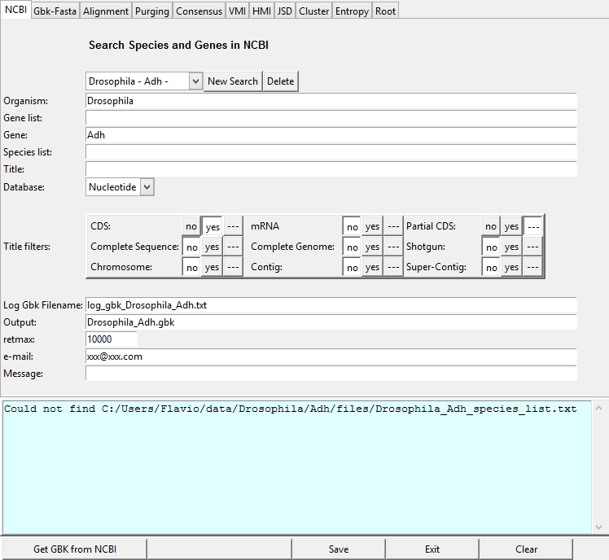

Now you have four alternatives to start your analysis:

1. Click in [Get GBK from NCBI] and you will download all gbk from the organism “Drosophila” and gene “Adh”.
2. Change “Adh” to “AMY” and in Gene List write “AMY, AMYREL”, and click in [Get GBK from NCBI] and you will analyze a short and interesting sample data.
3. You also may define your own Organism and Gene. If necessary you may define words in Title to find any desired gene-experiment.
4. Another possible way is to see a previous analysis that we did. In mia/data you will find 2 set of samples. One for “Adh” and the other for “AMY”.
- click in “save” and exit the MIA program
- look for:
  - in windows: c:\user\your_name\Drosophila\data
  - in linux: ~/Drosophila/data
- you will find /data/Adh
- create also /data/AMY
- go to your clone/download directory and find data/adh and data/AMY
- copy each fasta.rar and files.rar to its respective directory
- decompress and you will find:
  - ../ Drosophila/data/Adh/fasta
  - ../ Drosophila/data/Adh/files
- both directories have many files inside
- in mia/data you will find **“default.ini”**, **overwrite** it in ../ Drosophila/ data
- find again MIA executable (binary) and **start it**
- in the first combo box you will find " Drosophila - Adh" and " Drosophila - AMY“.
- choose one of these options
- jump (click) in VMI, or HMI, or JSD or Cluster and see the results
- any other information look in the MIA manual, please